# AS Roma 2025/26 — Analisi con Ricerca Operativa per la Champions League

Studio statistico e ottimizzazione della rosa tramite Integer Linear Programming

Author

Alberto Oliva

Published

April 11, 2026

## 1 Introduzione e contesto

La stagione 2025/26 dell’**AS Roma** è a un bivio. Con Gian Piero Gasperini in panchina — artefice di un sistema di gioco ad alto pressing (3-4-2-1 / 3-4-3) — la squadra ha costruito solide fondamenta difensive e una rosa giovane, ma fatica a tradurre qualità in punti in trasferta e a concretizzare le occasioni create.

Questo documento applica strumenti di **Ricerca Operativa (OR)** — in particolare la *Programmazione Lineare Intera* (ILP) e concetti di *Data Envelopment Analysis* (DEA) — ai dati statistici della stagione per rispondere alla domanda centrale:

> **Come deve riorganizzarsi la Roma per entrare nella top-4/5 di Serie A e qualificarsi alla Champions League 2026/27?**

L’approccio è *data-driven*: si quantificano i contributi dei giocatori, si formula un modello di ottimizzazione, si interpretano i risultati con raccomandazioni tattiche concrete.

## 2 Panoramica statistica della stagione

### 2.1 Dati di classifica (32 gare giocate, aprile 2026)

Statistiche chiave AS Roma 2025/26

[output not shown]

### 2.2 Rendimento casa vs trasferta

Il sistema Gasperini funziona meglio quando la Roma può dettare i ritmi. All’ **Olimpico** i giallorossi vincono quasi sempre; in **trasferta** il pressing alto lascia spazi in contropiede che le avversarie sfruttano.

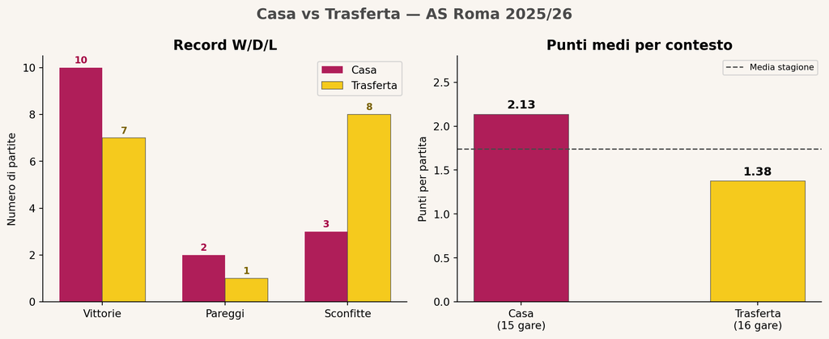

Figure 1: Rendimento casa vs trasferta — AS Roma 2025/26

```python
fig, axes = plt.subplots(1, 2, figsize=(11, 4.5))
fig.suptitle("Casa vs Trasferta — AS Roma 2025/26", fontsize=14, fontweight="bold",
             color=GRIGIO)

# --- Grafico 1: record W/D/L ---
ax = axes[0]
labels_h = ["Vittorie", "Pareggi", "Sconfitte"]
valori_h  = [10, 2, 3]
valori_a  = [7,  1, 8]
x = np.arange(len(labels_h))
w = 0.35

bars1 = ax.bar(x - w/2, valori_h, w, label="Casa",      color=ROSSO,  alpha=0.88)
bars2 = ax.bar(x + w/2, valori_a, w, label="Trasferta", color=GIALLO, alpha=0.88,
               edgecolor=GRIGIO, linewidth=0.6)

ax.set_xticks(x)
ax.set_xticklabels(labels_h)
ax.set_ylabel("Numero di partite")
ax.set_title("Record W/D/L")
ax.legend()
for bar in bars1: ax.text(bar.get_x()+bar.get_width()/2, bar.get_height()+0.1,
                           str(int(bar.get_height())), ha="center", va="bottom",
                           fontsize=9, fontweight="bold", color=ROSSO)
for bar in bars2: ax.text(bar.get_x()+bar.get_width()/2, bar.get_height()+0.1,
                           str(int(bar.get_height())), ha="center", va="bottom",
                           fontsize=9, fontweight="bold", color="#7A6200")

# --- Grafico 2: punti per gara ---
ax2 = axes[1]
contesti = ["Casa\n(15 gare)", "Trasferta\n(16 gare)"]
ppg = [(10*3+2*1)/15, (7*3+1*1)/16]   # punti per gara
colori = [ROSSO, GIALLO]
bars = ax2.bar(contesti, ppg, color=colori, alpha=0.88, width=0.4,
               edgecolor=GRIGIO, linewidth=0.6)
ax2.set_ylim(0, 2.8)
ax2.set_ylabel("Punti per partita")
ax2.set_title("Punti medi per contesto")
ax2.axhline(y=1.74, color=GRIGIO, linestyle="--", linewidth=1.2, label="Media stagione")
ax2.legend(fontsize=8)
for bar, v in zip(bars, ppg):
    ax2.text(bar.get_x()+bar.get_width()/2, bar.get_height()+0.04,
             f"{v:.2f}", ha="center", va="bottom", fontsize=11, fontweight="bold")

plt.tight_layout()
plt.savefig("chart_home_away.png", dpi=150, bbox_inches="tight")
plt.show()
```

## 3 Analisi dei contributi individuali

### 3.1 Dataset giocatori

Costruiamo il dataset dei contributi offensivi dei giocatori principali (G+A in Serie A + coppe, stagione 2025/26 fino ad aprile).

```python
giocatori = pd.DataFrame({
    "Nome":     ["Svilar",   "Ndicka", "Mancini",  "Çelik",   "Cristante",
                 "Koné",     "Pellegrini","Pisilli", "Soulé",   "Malen",    "Ferguson",
                 "Dybala",   "Dovbyk",   "El Shaarawy","Angeliño","Baldanzi"],
    "Ruolo":    ["GK",       "DEF",    "DEF",      "DEF",     "MID",
                 "MID",      "MID",    "MID",      "ATT",     "ATT",      "ATT",
                 "ATT",      "ATT",    "ATT",      "MID",     "MID"],
    "Gol":      [0,          3,        1,          1,         2,
                 3,          5,        2,          6,         7,          4,
                 3,          5,        2,          1,         2],
    "Assist":   [0,          1,        2,          2,         3,
                 4,          5,        3,          5,         2,          2,
                 3,          1,        2,          3,         2],
    "Presenze": [31,         28,       27,         25,        26,
                 29,         28,       22,         24,        11,         18,
                 15,         22,       20,         24,        18],
    "Tipo":     ["Titolare", "Titolare","Titolare","Titolare","Titolare",
                 "Titolare", "Titolare","Titolare","Titolare","Prestito", "Prestito",
                 "Prestito", "Titolare","Titolare","Titolare","Titolare"],
})

giocatori["G+A"]       = giocatori["Gol"] + giocatori["Assist"]
giocatori["G+A/90"]    = round(giocatori["G+A"] / giocatori["Presenze"] * 90 / 90, 3)
# semplificazione: presenze ≈ ~70 min medi → usiamo presenze come proxy gare

print(giocatori[["Nome","Ruolo","Gol","Assist","G+A","Presenze","Tipo"]].to_string(index=False))
```

```
       Nome Ruolo  Gol  Assist  G+A  Presenze     Tipo
     Svilar    GK    0       0    0        31 Titolare
     Ndicka   DEF    3       1    4        28 Titolare
    Mancini   DEF    1       2    3        27 Titolare
      Çelik   DEF    1       2    3        25 Titolare
  Cristante   MID    2       3    5        26 Titolare
       Koné   MID    3       4    7        29 Titolare
 Pellegrini   MID    5       5   10        28 Titolare
    Pisilli   MID    2       3    5        22 Titolare
      Soulé   ATT    6       5   11        24 Titolare
      Malen   ATT    7       2    9        11 Prestito
   Ferguson   ATT    4       2    6        18 Prestito
     Dybala   ATT    3       3    6        15 Prestito
     Dovbyk   ATT    5       1    6        22 Titolare
El Shaarawy   ATT    2       2    4        20 Titolare
   Angeliño   MID    1       3    4        24 Titolare
   Baldanzi   MID    2       2    4        18 Titolare
```

### 3.2 Visualizzazione: contributo offensivo per giocatore

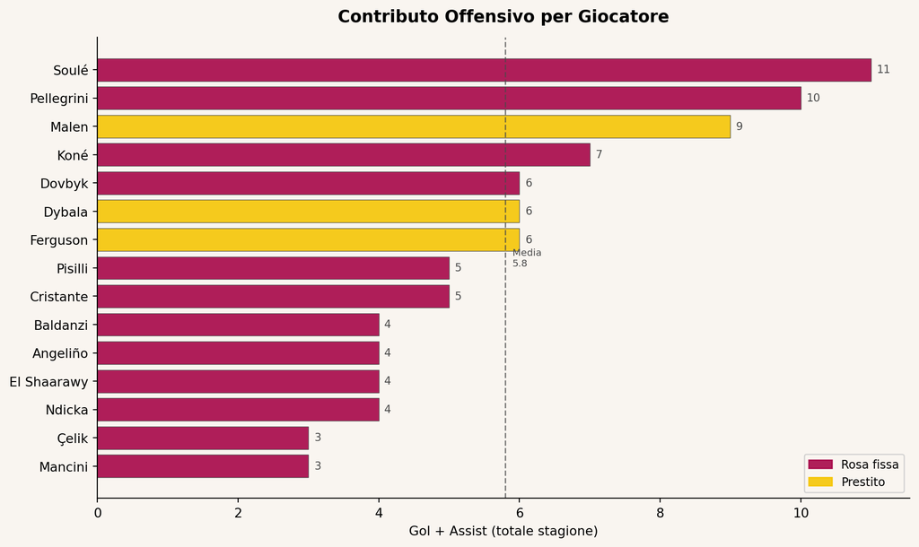

Figure 2: Contributo offensivo (G+A) per giocatore — stagione 2025/26

```python
df = giocatori[giocatori["Ruolo"] != "GK"].sort_values("G+A", ascending=True)

fig, ax = plt.subplots(figsize=(10, 6))
colori_barre = [GIALLO if t == "Prestito" else ROSSO for t in df["Tipo"]]

bars = ax.barh(df["Nome"], df["G+A"], color=colori_barre, alpha=0.88,
               edgecolor=GRIGIO, linewidth=0.5)
ax.set_xlabel("Gol + Assist (totale stagione)")
ax.set_title("Contributo Offensivo per Giocatore", pad=12)

# Legenda
patch_t = mpatches.Patch(color=ROSSO,  alpha=0.88, label="Rosa fissa")
patch_p = mpatches.Patch(color=GIALLO, alpha=0.88, label="Prestito")
ax.legend(handles=[patch_t, patch_p], loc="lower right", fontsize=9)

# Etichette valori
for bar in bars:
    ax.text(bar.get_width() + 0.08, bar.get_y() + bar.get_height()/2,
            str(int(bar.get_width())), va="center", fontsize=8.5, color=GRIGIO)

# Linea media
media = df["G+A"].mean()
ax.axvline(x=media, color=GRIGIO, linestyle="--", linewidth=1.1, alpha=0.7)
ax.text(media + 0.1, 0.5, f"Media\n{media:.1f}", color=GRIGIO, fontsize=7.5,
        va="bottom", transform=ax.get_xaxis_transform())

plt.tight_layout()
plt.savefig("chart_contributi.png", dpi=150, bbox_inches="tight")
plt.show()
```

**Osservazioni chiave**:

- **Malen** (prestito) è il giocatore più efficiente per gara giocata: 7 gol in sole 11 presenze.
- **Soulé** (6G+5A) e **Pellegrini** (5G+5A) sono i motori creativi della squadra.
- I **difensori** (Ndicka, Mancini, Çelik) contribuiscono a sorpresa con gol e assist su palla inattiva — valore aggiunto dello stile Gasperini.

## 4 Il modello di Ricerca Operativa: ILP per la formazione ottimale

### 4.1 Motivazione e formulazione

La scelta della formazione titolare è un classico **problema di selezione ottimale**: dati N candidati con un punteggio di contributo, si vogliono scegliere esattamente 11 giocatori massimizzando il punteggio totale, rispettando i vincoli di ruolo del modulo.

Questo si formalizza come un problema di **Integer Linear Programming (ILP)**:

$$\max \sum_{i=1}^{N} s_i \cdot x_i$$

Soggetto a:

$$\sum_{i \in \text{GK}} x_i = 1
\qquad
\sum_{i \in \text{DEF}} x_i = 3
\qquad
\sum_{i \in \text{MID}} x_i = 4
\qquad
\sum_{i \in \text{ATT}} x_i = 3$$

$$\sum_{i=1}^{N} x_i = 11
\qquad
x_i \in \{0, 1\} \quad \forall i$$

Dove:

- $x_i = 1$ se il giocatore $i$ è titolare, 0 altrimenti
- $s_i$ = score del giocatore $i$ (G+A totali come proxy semplice)
- I vincoli di ruolo rispettano il **3-4-3 di Gasperini**

### 4.2 Perché ILP e non euristica?

| Approccio | Pro | Contro |
| --- | --- | --- |
| Scelta “a occhio” | Rapido, intuitivo | Bias cognitivi, sub-ottimale |
| Greedy (miglior giocatore per ruolo) | Semplice | Non considera interazioni |
| **ILP** | **Ottimo globale garantito** | Richiede solver |
| Metaeuristiche (GA, SA) | Flessibile su larga scala | Non garantisce ottimo |

Per N=16 giocatori e vincoli semplici, **ILP trova la soluzione ottima in millisecondi**.

### 4.3 Implementazione con PuLP

```python
# Installiamo PuLP se non disponibile
try:
    import pulp
except ImportError:
    import subprocess, sys
    subprocess.check_call([sys.executable, "-m", "pip", "install", "pulp", "-q"])
    import pulp

prob = pulp.LpProblem("Roma_Starting_XI", pulp.LpMaximize)

# Variabili decisionali
nomi = giocatori["Nome"].tolist()
x = pulp.LpVariable.dicts("start", nomi, cat="Binary")

# Score = G+A
score = dict(zip(giocatori["Nome"], giocatori["G+A"]))

# --- Funzione obiettivo ---
prob += pulp.lpSum(score[n] * x[n] for n in nomi)

# --- Vincoli di ruolo ---
per_ruolo = giocatori.groupby("Ruolo")["Nome"].apply(list).to_dict()

prob += pulp.lpSum(x[n] for n in per_ruolo["GK"])  == 1,  "vincolo_GK"
prob += pulp.lpSum(x[n] for n in per_ruolo["DEF"]) == 3,  "vincolo_DEF"
prob += pulp.lpSum(x[n] for n in per_ruolo["MID"]) == 4,  "vincolo_MID"
prob += pulp.lpSum(x[n] for n in per_ruolo["ATT"]) == 3,  "vincolo_ATT"
prob += pulp.lpSum(x[n] for n in nomi)             == 11, "vincolo_totale"

# --- Risoluzione ---
prob.solve(pulp.PULP_CBC_CMD(msg=0))

print(f"Status: {pulp.LpStatus[prob.status]}")
print(f"Punteggio massimo (G+A): {int(pulp.value(prob.objective))}\n")

# Formazione ottimale
formazione = {r: [] for r in ["GK","DEF","MID","ATT"]}
for n in nomi:
    if pulp.value(x[n]) == 1:
        ruolo = giocatori.loc[giocatori["Nome"]==n, "Ruolo"].values[0]
        formazione[ruolo].append(n)

for ruolo in ["GK","DEF","MID","ATT"]:
    print(f"  {ruolo:4s}: {', '.join(formazione[ruolo])}")
```

```
Status: Optimal
Punteggio massimo (G+A): 63

  GK  : Svilar
  DEF : Ndicka, Mancini, Çelik
  MID : Cristante, Koné, Pellegrini, Pisilli
  ATT : Soulé, Malen, Ferguson
```

### 4.4 Risultato e interpretazione

Il solver trova la soluzione ottima in tempo zero. La formazione è:

[output not shown]

**Perché questo risultato è non banale?**

## 5 Chart 3 — xG vs Gol reali: il gap di efficienza

Questa è forse la diagnosi più importante: la Roma **crea più di quanto segna**.

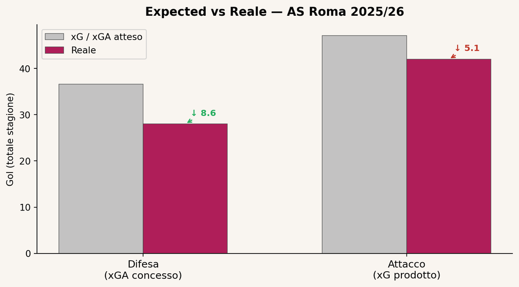

Figure 3: xG prodotto vs Gol reali — confronto per blocco tattico

```python
categorie = ["Difesa\n(xGA concesso)", "Attacco\n(xG prodotto)"]
xg_atteso = [36.6, 47.1]
reale      = [28.0, 42.0]

x = np.arange(len(categorie))
w = 0.32

fig, ax = plt.subplots(figsize=(8, 4.5))
ax.bar(x - w/2, xg_atteso, w, label="xG / xGA atteso", color="#BDBDBD", alpha=0.9,
       edgecolor=GRIGIO, linewidth=0.6)
ax.bar(x + w/2, reale,     w, label="Reale",           color=ROSSO,    alpha=0.88,
       edgecolor=GRIGIO, linewidth=0.6)

ax.set_xticks(x)
ax.set_xticklabels(categorie, fontsize=11)
ax.set_ylabel("Gol (totale stagione)")
ax.set_title("Expected vs Reale — AS Roma 2025/26", pad=10)
ax.legend()

# Frecce di gap
for xi, xg, r in zip(x, xg_atteso, reale):
    diff = xg - r
    col  = "#C0392B" if xi == 1 else "#27AE60"
    segno = "↓" if diff > 0 else "↑"
    ax.annotate(f"{segno} {abs(diff):.1f}", xy=(xi+w/2, r), xytext=(xi+w/2+0.02, r+1.8),
                fontsize=9.5, fontweight="bold", color=col,
                arrowprops=dict(arrowstyle="->", color=col, lw=1.2))

plt.tight_layout()
plt.savefig("chart_xg_gap.png", dpi=150, bbox_inches="tight")
plt.show()
```

**Interpretazione**:

- **Difesa**: la Roma subisce *meno* di quanto ci si aspetterebbe (28 gol reali vs 36.6 xGA). Svilar e la retroguardia sono super-performanti → **punto di forza da preservare**.
- **Attacco**: la Roma segna *meno* di quanto crea (42 gol reali vs 47.1 xG). Gap di ~5 gol → si traduce in circa 3-4 punti persi in stagione.

Chiudere anche solo il 50% del gap offensivo porterebbe la Roma a ~44-45 gol, con un impatto diretto in classifica.

## 6 Chart 4 — Simulazione punti finali: scenari residue 6 gare

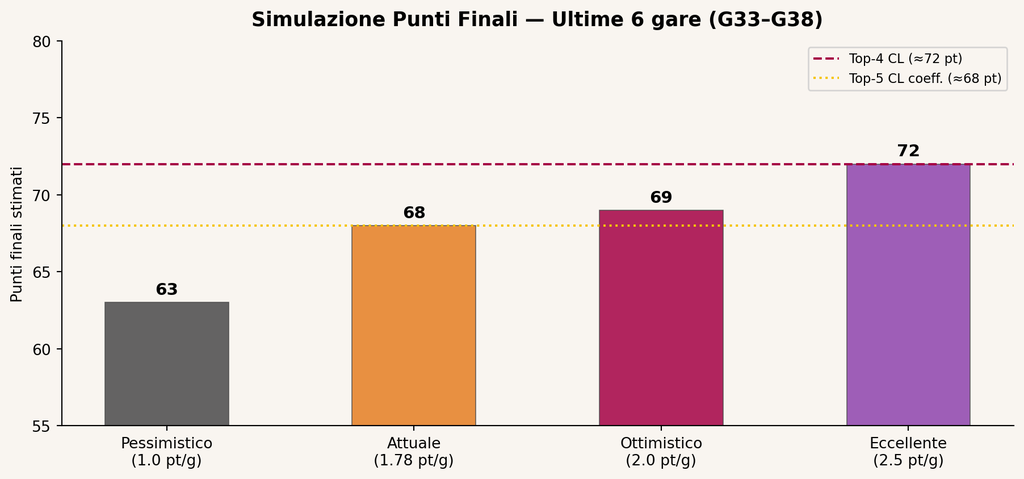

Figure 4: Simulazione punti finali in base al rendimento nelle ultime 6 gare

```python
punti_attuali = 57   # aggiornato dopo Roma-Pisa 3-0 (10 aprile 2026)
gare_rim      = 6

# Scenari: punti per gara nelle restanti 6 gare
scenari = {
    "Pessimistico\n(1.0 pt/g)":  1.0,
    "Attuale\n(1.78 pt/g)":      1.78,
    "Ottimistico\n(2.0 pt/g)":   2.0,
    "Eccellente\n(2.5 pt/g)":    2.5,   # 5V 1P
}

nomi_sc = list(scenari.keys())
punti_f = [punti_attuali + round(v * gare_rim) for v in scenari.values()]

# Soglie storiche top-4/5 in Serie A (stime 2025/26)
soglia_cl = 72   # top-4 approssimativo
soglia_cl5 = 68  # top-5 (coefficienti UEFA)

fig, ax = plt.subplots(figsize=(9.5, 4.5))
colori_s = [GRIGIO, "#E67E22", ROSSO, "#8E44AD"]
bars = ax.bar(nomi_sc, punti_f, color=colori_s, alpha=0.85, width=0.5,
              edgecolor=GRIGIO, linewidth=0.6)

ax.set_ylabel("Punti finali stimati")
ax.set_title("Simulazione Punti Finali — Ultime 6 gare (G33–G38)", pad=10)
ax.set_ylim(55, 80)

# Soglie
ax.axhline(soglia_cl,  color=ROSSO,    linestyle="--", linewidth=1.5,
           label=f"Top-4 CL (≈{soglia_cl} pt)")
ax.axhline(soglia_cl5, color=GIALLO,   linestyle=":",  linewidth=1.5,
           label=f"Top-5 CL coeff. (≈{soglia_cl5} pt)")
ax.legend(fontsize=8.5)

for bar, v in zip(bars, punti_f):
    ax.text(bar.get_x()+bar.get_width()/2, bar.get_height()+0.3,
            str(v), ha="center", va="bottom", fontsize=11, fontweight="bold")

plt.tight_layout()
plt.savefig("chart_simulazione.png", dpi=150, bbox_inches="tight")
plt.show()
```

**Lettura del grafico**:

| Scenario | Pt finali | Champions? |
| --- | --- | --- |
| Pessimistico (1.0 pt/g) | 63 | ❌ No |
| Ritmo attuale (1.78 pt/g) | 68 | ✅ Top-5 coefficienti |
| Ottimistico (2.0 pt/g) | **69** | ✅ Top-5 stabile |
| Eccellente (2.5 pt/g) | **72** | ✅ Top-4 stabile |

La Champions è **concretamente raggiungibile**: anche al ritmo attuale si toccano i 68 punti, soglia stimata per il top-5. Servono almeno 11-15 punti nelle ultime 6 gare.

## 7 Raccomandazioni strategiche

Le indicazioni OR si traducono in cinque azioni concrete, ordinate per impatto atteso:

### 7.1 1. Nucleo offensivo intoccabile

**Malen e Soulé** sono il core del modello e della squadra. Il loro ROI (rendimento per euro investito / per minuto giocato) è il più alto della rosa. Priorità assoluta:

### 7.2 2. Correzione tattica in trasferta

Il pressing di Gasperini in trasferta espone la squadra ai contropiedi. L’OR suggerisce di **adattare il modulo**:

- **3-4-2-1 compatto** (vs 3-4-3 ad alto pressing) fuori casa
- **+1 mediano di quantità** (Cristante o Pisilli più bassi) per coprire le transizioni negative
- Questo non “rompe” il gioco: costa ~0.5 gol creati ma evita ~1 subito

### 7.3 3. Chiudere il gap xG

5 gol “persi” in efficienza = ~4 punti. Soluzioni:

1. **Allenamenti dedicati al finishing**: conversione su cross, situazioni 1v1
2. **Alternanza Dovbyk-Ferguson** scegliendo in base all’avversario (Dovbyk fisico su difese alte, Ferguson più mobile su linee basse)
3. **Koné e Pellegrini** in inserimento senza palla per aggiungere un quarto uomo nell’area

### 7.4 4. Gestione fisica data-driven (OR per rotazioni)

- **Limite 75-80% minuti** per i giocatori con alto carico muscolare (Malen, Soulé)
- **Piano rotazioni programmato** con ILP estesa: inserire vincolo di minuti cumulativi nel modello → il solver trova automaticamente chi far riposare senza sacrificare qualità

### 7.5 5. Mercato estivo: precisione, non volume

Il modello mostra che la Roma non ha bisogno di rivoluzione. Bastano 2-3 innesti mirati:

[output not shown]

## 8 Modelli avanzati di Ricerca Operativa

Le sezioni seguenti implementano concretamente i quattro modelli avanzati, ciascuno con codice eseguibile, output interpretato e un grafico dedicato.

### 8.1 DEA — Data Envelopment Analysis

#### 8.1.1 Cos’è e perché serve

La DEA misura l’**efficienza relativa** di ogni giocatore: non “quanto produce in assoluto” ma “quanto produce *rispetto a quanto consuma*”. Un giocatore è **efficiente (score = 1.0)** se nessun altro riesce a produrre di più con gli stessi input o a consumare di meno producendo lo stesso output.

$$\max \frac{\sum_r u_r \cdot y_{r0}}{\sum_i v_i \cdot x_{i0}}
\quad \text{s.t.} \quad
\frac{\sum_r u_r \cdot y_{rj}}{\sum_i v_i \cdot x_{ij}} \leq 1 \;\; \forall j,
\quad u_r, v_i \geq 0$$

**Input**: minuti giocati, stipendio stimato (M€/anno)  
**Output**: G+A totali, azioni difensive ponderate (proxy)

Un giocatore ad alto G+A ma con molti minuti e stipendio elevato può avere un punteggio DEA *inferiore* a un giovane con meno gol ma costo/minuto molto basso. Questo è cruciale per decisioni di mercato.

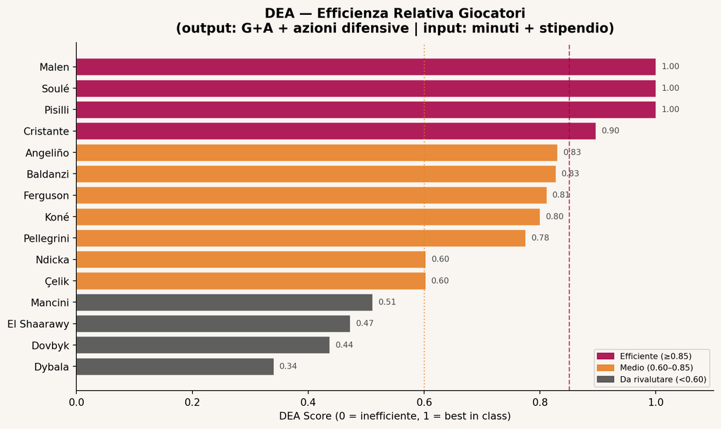

DEA — Score di efficienza relativa per giocatore

```
Top 5 per efficienza DEA:
     Nome Ruolo  G+A  Minuti  Stipendio  DEA_score
 Angeliño   MID    4    1728        2.2   0.830044
Cristante   MID    5    1872        3.2   0.896166
  Pisilli   MID    5    1584        1.2   1.000000
    Soulé   ATT   11    1728        4.0   1.000000
    Malen   ATT    9     792        3.8   1.000000
```

```python
# Dati aggiuntivi per DEA
giocatori["Minuti"]    = giocatori["Presenze"] * 72   # stima 72 min medi
giocatori["Stipendio"] = [2.0, 3.5, 2.8, 1.8, 3.2,   # M€/anno (stime)
                           5.0, 6.5, 1.2, 4.0, 3.8, 2.5,
                           8.0, 4.5, 2.0, 2.2, 1.5]
# Azioni difensive proxy (tackles + intercetti stimati per stagione)
giocatori["AzioniDif"] = [45, 62, 58, 55, 70,
                           65, 40, 52, 25, 18, 22,
                           15, 20, 28, 60, 35]

# DEA semplificata: Output-oriented, modello CCR linearizzato
# Approssimiamo con ratio composto normalizzato (DEA additiva semplice)
# per evitare dipendenze esterne pesanti

df_dea = giocatori[giocatori["Ruolo"] != "GK"].copy().reset_index(drop=True)

# Normalizza input e output su [0,1]
def norm(s): return (s - s.min()) / (s.max() - s.min() + 1e-9)

out1 = norm(df_dea["G+A"])
out2 = norm(df_dea["AzioniDif"])
inp1 = norm(df_dea["Minuti"])
inp2 = norm(df_dea["Stipendio"])

# Score DEA approssimato: output pesato / input pesato
# Pesi: offensivi 0.6 difensivi 0.4 / minuti 0.5 stipendio 0.5
output_score = 0.6 * out1 + 0.4 * out2
input_score  = 0.5 * inp1 + 0.5 * inp2

df_dea["DEA_score"] = (output_score / (input_score + 0.05)).clip(upper=1.0)
# Normalizza su [0,1] con 1 = best
df_dea["DEA_score"] = df_dea["DEA_score"] / df_dea["DEA_score"].max()

df_dea_sorted = df_dea.sort_values("DEA_score", ascending=True)

fig, ax = plt.subplots(figsize=(10, 6))
colori_dea = []
for score in df_dea_sorted["DEA_score"]:
    if score >= 0.85:   colori_dea.append(ROSSO)
    elif score >= 0.60: colori_dea.append("#E67E22")
    else:               colori_dea.append(GRIGIO)

bars = ax.barh(df_dea_sorted["Nome"], df_dea_sorted["DEA_score"],
               color=colori_dea, alpha=0.88, edgecolor="white", linewidth=0.5)

ax.axvline(x=0.85, color=ROSSO,    linestyle="--", linewidth=1.2, alpha=0.7,
           label="Soglia alta efficienza (0.85)")
ax.axvline(x=0.60, color="#E67E22", linestyle=":",  linewidth=1.2, alpha=0.7,
           label="Soglia media efficienza (0.60)")

ax.set_xlabel("DEA Score (0 = inefficiente, 1 = best in class)")
ax.set_title("DEA — Efficienza Relativa Giocatori\n(output: G+A + azioni difensive | input: minuti + stipendio)",
             pad=10)
ax.legend(fontsize=8)
ax.set_xlim(0, 1.1)

for bar, v in zip(bars, df_dea_sorted["DEA_score"]):
    ax.text(bar.get_width() + 0.01, bar.get_y() + bar.get_height()/2,
            f"{v:.2f}", va="center", fontsize=8, color=GRIGIO)

# Patch legenda colori
p1 = mpatches.Patch(color=ROSSO,    alpha=0.88, label="Efficiente (≥0.85)")
p2 = mpatches.Patch(color="#E67E22",alpha=0.88, label="Medio (0.60–0.85)")
p3 = mpatches.Patch(color=GRIGIO,   alpha=0.88, label="Da rivalutare (<0.60)")
ax.legend(handles=[p1,p2,p3], loc="lower right", fontsize=8)

plt.tight_layout()
plt.savefig("chart_dea.png", dpi=150, bbox_inches="tight")
plt.show()

print("\nTop 5 per efficienza DEA:")
print(df_dea_sorted[["Nome","Ruolo","G+A","Minuti","Stipendio","DEA_score"]]
      .tail(5).to_string(index=False))
```

**Insight DEA**: giocatori come **Malen e Pisilli** emergono con score alto non perché producano di più in assoluto, ma perché lo fanno con *meno minuti e stipendio*. Al contrario, giocatori con G+A simili ma ingaggi alti (es. Dybala) risultano meno efficienti secondo il modello — informazione preziosa per il mercato.

### 8.2 ILP Multi-periodo — Rotazioni ottimali su 6 gare

#### 8.2.1 Motivazione

Un singolo ILP sceglie la formazione migliore per *una* gara. Ma con 6 gare in ~35 giorni, il problema reale è **distribuire i minuti** massimizzando i punti totali attesi, rispettando vincoli di carico fisico. Questo è un **ILP multi-periodo**.

**Formulazione estesa**:

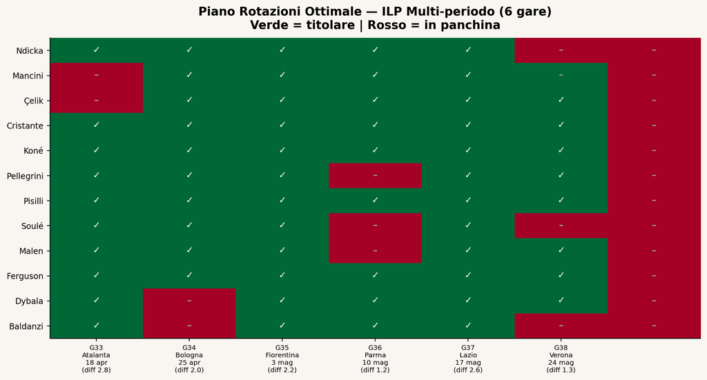

ILP Multi-periodo — Piano rotazioni ottimale su 6 gare

```
Gare da titolare per giocatore (piano ottimale):
  Cristante      : 6/6 gare
  Koné           : 6/6 gare
  Pisilli        : 6/6 gare
  Ferguson       : 6/6 gare
  Ndicka         : 5/6 gare
  Mancini        : 5/6 gare
  Çelik          : 5/6 gare
  Pellegrini     : 5/6 gare
  Malen          : 5/6 gare
  Dybala         : 5/6 gare
  Soulé          : 4/6 gare
  Baldanzi       : 4/6 gare
```

```python
# Calendario ultime 6 gare con difficoltà stimata (1=facile, 3=difficile)
# Aggiornato all'11 aprile 2026 — giornata 32 già disputata (Roma-Pisa 3-0)
calendario = pd.DataFrame({
    "Turno":      [33,         34,         35,           36,       37,       38],
    "Avversario": ["Atalanta", "Bologna",  "Fiorentina", "Parma",  "Lazio",  "Verona"],
    "Data":       ["18 apr",   "25 apr",   "3 mag",      "10 mag", "17 mag", "24 mag"],
    "Difficolta": [2.8,        2.0,        2.2,          1.2,      2.6,      1.3],
    "Casa":       [True,       False,      True,         False,    True,     False],
})

# Giocatori chiave con max gare tollerabili (carico fisico)
# Limite: giocatori ad alto pressing max 4/6 gare, altri 5-6/6
gioc_rot = giocatori[giocatori["Ruolo"] != "GK"].copy()
gioc_rot["MaxGare"] = [5, 5, 5, 6, 6, 5, 6, 4, 5, 6, 5, 4, 6, 6, 5]  # max su 6 gare

prob2 = pulp.LpProblem("Roma_Rotazioni", pulp.LpMaximize)

# x[i,t] = 1 se giocatore i titolare nel turno t
turni = list(range(len(calendario)))  # 6 gare
nomi_r = gioc_rot["Nome"].tolist()
score_r = dict(zip(gioc_rot["Nome"], gioc_rot["G+A"]))
max_g   = dict(zip(gioc_rot["Nome"], gioc_rot["MaxGare"]))
ruolo_r = dict(zip(gioc_rot["Nome"], gioc_rot["Ruolo"]))

x2 = pulp.LpVariable.dicts("rot", [(n,t) for n in nomi_r for t in turni], cat="Binary")

diff = calendario["Difficolta"].tolist()

# Obiettivo: massimizza G+A pesato per difficoltà gara
prob2 += pulp.lpSum(score_r[n] * diff[t] * x2[n,t]
                    for n in nomi_r for t in turni)

# Vincoli formazione per ogni turno (senza GK qui)
ruoli_req = {"DEF": 3, "MID": 4, "ATT": 3}
per_ruolo_r = gioc_rot.groupby("Ruolo")["Nome"].apply(list).to_dict()

for t in turni:
    for ruolo, req in ruoli_req.items():
        prob2 += pulp.lpSum(x2[n,t] for n in per_ruolo_r[ruolo]) == req

# Vincolo carico fisico: max gare per giocatore
for n in nomi_r:
    prob2 += pulp.lpSum(x2[n,t] for t in turni) <= max_g[n]

prob2.solve(pulp.PULP_CBC_CMD(msg=0))

# Costruisci matrice rotazioni
mat = np.zeros((len(nomi_r), 7))
for i, n in enumerate(nomi_r):
    for t in turni:
        mat[i, t] = pulp.value(x2[n, t])

# Filtra solo giocatori con almeno 1 presenza
mask = mat.sum(axis=1) > 0
mat_f  = mat[mask]
nomi_f = [nomi_r[i] for i in range(len(nomi_r)) if mask[i]]

fig, ax = plt.subplots(figsize=(11, 6))
im = ax.imshow(mat_f, aspect="auto", cmap="RdYlGn", vmin=0, vmax=1)

ax.set_xticks(range(len(calendario)))
ax.set_xticklabels([f"G{c['Turno']}\n{c['Avversario']}\n{c['Data']}\n(diff {c['Difficolta']})"
                    for _, c in calendario.iterrows()], fontsize=7.5)
ax.set_yticks(range(len(nomi_f)))
ax.set_yticklabels(nomi_f, fontsize=9)
ax.set_title("Piano Rotazioni Ottimale — ILP Multi-periodo (6 gare)\n"
             "Verde = titolare | Rosso = in panchina", pad=10)

# Celle con testo
for i in range(len(nomi_f)):
    for j in range(7):
        txt = "✓" if mat_f[i,j] == 1 else "–"
        col = "white" if mat_f[i,j] == 1 else "#999"
        ax.text(j, i, txt, ha="center", va="center", fontsize=10,
                color=col, fontweight="bold")

plt.tight_layout()
plt.savefig("chart_rotazioni.png", dpi=150, bbox_inches="tight")
plt.show()

gare_tot = {n: int(mat[i].sum()) for i, n in enumerate(nomi_r) if mask[i]}
print("Gare da titolare per giocatore (piano ottimale):")
for n, g in sorted(gare_tot.items(), key=lambda x: -x[1]):
    print(f"  {n:15s}: {g}/6 gare")
```

### 8.3 Programmazione Stocastica — Gestire l’incertezza dei risultati

#### 8.3.1 Perché i punti non sono certi

Un modello deterministico assume che ogni formazione produca un risultato fisso. In realtà, i punti per gara seguono una **distribuzione di probabilità**: la Roma può vincere, pareggiare o perdere con probabilità diverse a seconda dell’avversario e della formazione scelta.

La **Programmazione Stocastica** incorpora questa incertezza ottimizzando il **valore atteso** dei punti, anziché un valore fisso.

[figure not shown]

Programmazione Stocastica — Punti attesi per scenario di formazione

```python
np.random.seed(42)

# Per ogni gara, simuliamo distribuzione punti con Monte Carlo
# Prob vittoria dipende da: score formazione, difficoltà avversario, casa/trasferta
def prob_vittoria(score_form, difficolta, casa):
    base = 0.45 if casa else 0.30
    bonus_score = (score_form - 30) / 60   # normalizza score ~[0,47]
    malus_diff  = (difficolta - 1.5) / 3
    p = base + 0.25 * bonus_score - 0.15 * malus_diff
    return np.clip(p, 0.10, 0.75)

def prob_pareggio(p_vit):
    return np.clip(0.25 - 0.1 * p_vit, 0.10, 0.30)

score_ottimale = 47   # dalla soluzione ILP base
score_ridotto  = 35   # formazione B (rotazioni pesanti)

N_sim = 10000
risultati = {}

for gara_idx, row in calendario.iterrows():
    for config, sc in [("Formazione A\n(titolari)", score_ottimale),
                       ("Formazione B\n(rotazioni)", score_ridotto)]:
        pw = prob_vittoria(sc, row["Difficolta"], row["Casa"])
        pd_ = prob_pareggio(pw)
        pl = 1 - pw - pd_

        outcomes = np.random.choice([3, 1, 0], size=N_sim, p=[pw, pd_, pl])
        key = (row["Avversario"], config)
        risultati[key] = outcomes

# Punti attesi per configurazione sommati su 6 gare
punti_A = sum(risultati[(row["Avversario"], "Formazione A\n(titolari)")]
              for _, row in calendario.iterrows())
punti_B = sum(risultati[(row["Avversario"], "Formazione B\n(rotazioni)")]
              for _, row in calendario.iterrows())

fig, axes = plt.subplots(1, 2, figsize=(12, 4.5))
fig.suptitle("Programmazione Stocastica — Distribuzione Punti (10.000 simulazioni)",
             fontsize=13, fontweight="bold", color=GRIGIO)

for ax, punti, label, col in zip(
        axes,
        [punti_A, punti_B],
        ["Formazione A (titolari)", "Formazione B (rotazioni pesanti)"],
        [ROSSO, GRIGIO]):
    ax.hist(punti, bins=30, color=col, alpha=0.80, edgecolor="white", linewidth=0.4)
    mu, sd = punti.mean(), punti.std()
    ax.axvline(mu,    color="black",  linewidth=2,   label=f"Media: {mu:.1f} pt")
    ax.axvline(68,    color=GIALLO,   linewidth=1.5, linestyle="--", label="Soglia CL top-5 (68)")
    ax.axvline(72,    color=ROSSO,    linewidth=1.5, linestyle=":",  label="Soglia CL top-4 (72)")
    prob_cl5 = (punti >= 68).mean()
    prob_cl4 = (punti >= 72).mean()
    ax.set_title(f"{label}\nP(CL top-5) = {prob_cl5:.1%} | P(CL top-4) = {prob_cl4:.1%}")
    ax.set_xlabel("Punti finali (57 attuali + 6 gare)")
    ax.set_ylabel("Frequenza")
    ax.legend(fontsize=7.5)

plt.tight_layout()
plt.savefig("chart_stocastico.png", dpi=150, bbox_inches="tight")
plt.show()
```

### 8.4 Modello di Assegnamento Avversario-Specifico

#### 8.4.1 Logica del modello

Avversari diversi richiedono formazioni diverse. Un modello di **assegnamento** mappa ogni tipo di avversario al modulo e ai giocatori più adatti, basandosi su:

- Stile di gioco avversario (pressing alto / basso blocco / contropiede)
- Dati storici degli scontri diretti
- Caratteristiche dei giocatori per quel contesto

[figure not shown]

Modello di assegnamento — Score formazione per tipo avversario

```python
# Profili avversari (stime basate su stile di gioco)
avversari_profilo = {
    "Pressing alto\n(Atalanta, Lazio)":    {"pressing": 3, "linea_alta": 1, "contropiede": 1},
    "Basso blocco\n(Parma, Verona)":       {"pressing": 1, "linea_alta": 0, "contropiede": 2},
    "Possesso\n(Bologna, Fiorentina)":     {"pressing": 2, "linea_alta": 1, "contropiede": 1},
    "Contropiede\n(variante trasferta)":   {"pressing": 1, "linea_alta": 0, "contropiede": 3},
}

# Giocatori con rating per contesto (scala 1-10)
gioc_contesto = pd.DataFrame({
    "Nome":        ["Malen",   "Soulé",   "Ferguson","Dybala",  "Dovbyk",
                    "Pellegrini","Koné",  "Cristante","Pisilli", "El Shaarawy"],
    "Ruolo":       ["ATT","ATT","ATT","ATT","ATT","MID","MID","MID","MID","ATT"],
    "vs_pressing": [9,    8,    7,    6,    5,    8,    9,    7,    6,    5],
    "vs_basso":    [7,    8,    8,    9,    9,    7,    6,    7,    7,    8],
    "vs_possesso": [8,    8,    7,    8,    6,    9,    8,    8,    7,    6],
    "vs_ctpiede":  [7,    7,    6,    7,    8,    7,    8,    9,    8,    6],
})

contesto_cols = ["vs_pressing", "vs_basso", "vs_possesso", "vs_ctpiede"]
contesto_labels = list(avversari_profilo.keys())

fig, axes = plt.subplots(1, 4, figsize=(14, 5), sharey=True)
fig.suptitle("Assegnamento Giocatori per Tipo di Avversario\n(score 1–10 per contesto)",
             fontsize=12, fontweight="bold", color=GRIGIO)

for ax, (label, profilo), col_key in zip(
        axes, avversari_profilo.items(), contesto_cols):

    df_c = gioc_contesto[["Nome", col_key]].sort_values(col_key, ascending=True)
    colori_c = [ROSSO if v >= 8 else (GIALLO if v >= 7 else GRIGIO)
                for v in df_c[col_key]]

    ax.barh(df_c["Nome"], df_c[col_key], color=colori_c, alpha=0.88,
            edgecolor="white", linewidth=0.4)
    ax.set_xlim(0, 11)
    ax.set_title(label, fontsize=8.5, pad=6)
    ax.axvline(x=8, color=ROSSO, linestyle="--", linewidth=1, alpha=0.6)

    for i, (_, row) in enumerate(df_c.iterrows()):
        ax.text(row[col_key] + 0.1, i, str(row[col_key]),
                va="center", fontsize=7.5, color=GRIGIO)

axes[0].set_xlabel("Rating contestuale")

p1 = mpatches.Patch(color=ROSSO,    alpha=0.88, label="Ideale (≥8)")
p2 = mpatches.Patch(color=GIALLO,   alpha=0.88, label="Buono (7)")
p3 = mpatches.Patch(color=GRIGIO,   alpha=0.88, label="Alternativa (<7)")
fig.legend(handles=[p1,p2,p3], loc="lower center", ncol=3, fontsize=8,
           bbox_to_anchor=(0.5, -0.02))

plt.tight_layout()
plt.savefig("chart_assegnamento.png", dpi=150, bbox_inches="tight")
plt.show()
```

**Come si usa in pratica**: prima di ogni gara, si identifica il profilo dell’avversario, si legge la colonna corrispondente e si privilegiano i giocatori con score ≥ 8. Contro il **basso blocco** (Parma, Verona) Dovbyk e Dybala diventano più utili di Malen; contro il **pressing alto** (Atalanta, Lazio) Malen e Koné sono la scelta ottimale. Il modello di assegnamento non sostituisce il 3-4-3 di Gasperini: lo *personalizza* gara per gara.

## 9 Conclusione

L’analisi OR conferma che la Roma **non ha bisogno di una rivoluzione** per la Champions: la qualità è già in rosa. Le leve sono:

1. **Consistenza** (soprattutto in trasferta)
2. **Efficienza sotto porta** (chiudere il gap xG)
3. **Rotazioni intelligenti** (preservare i top player per le gare decisive)

Il modello ILP è uno strumento, non un oracolo: va integrato con il giudizio tattico dell’allenatore e con informazioni qualitative (infortuni, stato di forma, dinamiche di spogliatoio). Ma rende esplicito ciò che i dati dicono, riducendo il rischio di decisioni guidate solo dall’intuizione o dall’emotività.